# Week 5

```r
v1=c()
for (i in week5data2){
  v1 = c(v1, mean(i))
}
v2=c()
for (i in week5data2){
  v2 = c(v2, sd(i))
}
mm=mean(v1)
msd=sd(v1)
sig3max=mm+3*msd
sig3min=mm-3*msd
drowPlot=function(dat, p1, p2){
  mymin = p1 - 1
  mymax = p2 + 1

  plot(dat$process1, type="p", ylim=c(mymin, mymax), axes=F, ylab="", col="2")
  par(new=T)
  plot(dat$process2, type="p", ylim=c(mymin, mymax), axes=F, ylab="", col="3")
  par(new=T)
  plot(dat$process3, type="p", ylim=c(mymin, mymax), axes=F, ylab="", col="4")
  par(new=T)
  plot(dat$process4, type="p", ylim=c(mymin, mymax), axes=F, ylab="", col="5")
  par(new=T)
  plot(dat$process5, type="p", ylim=c(mymin, mymax), axes=F, ylab="", col="6")
  par(new=T)
}
makeSummary = function(val){
  mat = matrix(seekInterval(val$process1), ncol=7)
  mat=rbind(mat, seekInterval(val$process2))
  mat=rbind(mat, seekInterval(val$process3))
  mat=rbind(mat, seekInterval(val$process4))
  mat=rbind(mat, seekInterval(val$process5))
  mat=rbind(mat, seekInterval(
    c(
      val$process1,
      val$process2,
      val$process3,
      val$process4,
      val$process5
    )
  ))
  colnames(mat)=c(
    "variance",
    "95% conf - bottom",
    "95% conf - top",
    "deviation - bottom",
    "deviation - top",
    "mean",
    "stndard deviation"
  )

  rownames(mat) = c(
    "process 1",
    "process 2",
    "process 3",
    "process 4",
    "process 5",
    "all process"
  )

  return(mat)
}
seekInterval = function(val){
  v=var(val)
  df=length(val)-1
  b = df*v/qchisq(0.975, df)
  t = df*v/qchisq(0.025, df)
  m = mean(val)
  stdd = sd(val)

  return(c(v, b, t, sqrt(b), sqrt(t), m, stdd))
}
drowHist = function(dat, val){
  myHist=hist(dat, breaks="Sturges", main = val)
  par(new=T)
  curve(
    dnorm(x, mean(dat), sd(dat)),
    xlim=c(min(myHist$breaks), max(myHist$breaks)),
    xlab="", ylab="",
    xaxt="n", yaxt="n",
    bty="n"
  )
}
drawCurve = function(val){
  nr = nrow(val)

  for (i in 1:nr){
    if (i != nr){
      curve(
        dnorm(x, val[i,6], val[i,7]),
        xlim=c(0, 10),
        col=i + 1,
        lty="dotted",
        axes=F,
        ylab=""
      )
      par(new=T)
    }
    else{
      curve(
        dnorm(x, val[i,6], val[i,7]),
        xlim=c(0, 10),
        col="1",
        ylab=""
      )
    }
  }
}
makeConclusion=function(val){
  nr = nrow(val)

  for (i in 1:nr){
    m = val[i ,6]
    b = val[i, 4]
    t = val[i, 5]
    s2.b = m - 2 * t
    s2.t = m + 2 * t

    if (i == 1){
      mat = matrix(c(m, b, t, s2.b, s2.t), ncol = 5)
    }
    else{
      mat = rbind(mat, matrix(c(m, b, t, s2.b, s2.t), ncol = 5))
    }
  }

  colnames(mat) = c(
    "mean",
    "deviation - bottom",
    "deviation - top",
    "2 sigma - bottom",
    "2 sigma - top"
  )

    rownames(mat) = c(
    "process 1",
    "process 2",
    "process 3",
    "process 4",
    "process 5",
    "all process"
  )

  return(mat)
}
```

## 1. Plot sample means for 40 days (mean chart) and see what is going on

- mean = 4.9735
- Although mean of 200 samples are close to 5.0, the ideal value ultimately,
- its daily mean is non-constant. –> daily quality is not equal.
- something (certain process, transmission or both) impacts mean value.

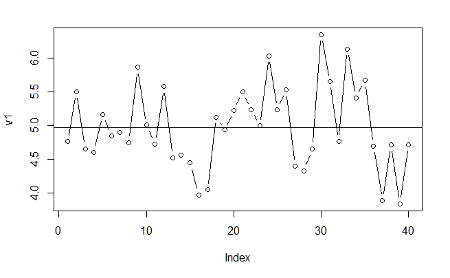

```r
plot(v1, type="b")
abline(h=mm)
```

## 2. Set internal control criteria as plus/minus 3 standard deviation of sample means and check the control status

- standard deviation = 0.6023862
- 3 sigma (bottom) = 3.1663415
- 3 sigma (top) = 6.7806585
- Assumption 1: daily mean should close to 5.0, the ideal value.
- Assumption: outside 3 sigmas is defined as a rejected product.

```r
par(mar=c(5,4,4,5))
plot(v1, type="l", ylim=c(sig3min-1, sig3max+1), ylab="")
par(new=T)
```

```r
drowPlot(week5data1, sig3min, sig3max)
abline(h=mm)
```

```r
abline(h=sig3max)
abline(h=sig3min)
```

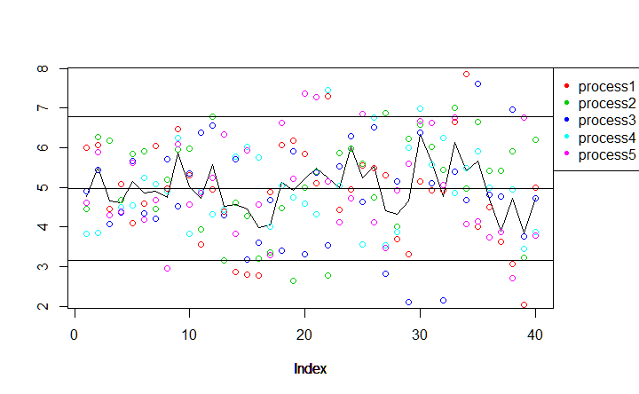

```r
par(xpd=T)
legend(par()$usr[2], par()$usr[4], legend=colnames(week5data1), pch=20, col=2:6)
```

## 3. Plot Standard Deviation of samples for 40 days (SD chart) and evaluate the process control

```r
p1=mean(v2)
p2=sd(v2)
p3=p1+2*p2
p4=p1-2*p2
```

- sample stnadard devisation -> SAMPLE
- mean of SAMPLE = 1.1299792
- standard deviation of SAMPLE = 0.407486
- 2 sigmas of SAMPLE = 1.9449512, 0.3150073
- sample SD mean of 200 samples indicates ultimate fluctuation of quality.
- its daily mean is non-constant. –> daily quality among processes is not equal.
- something (certain process, transmission or both) impacts mean value.

```r
plot(v2, type="b")
abline(h=p1)
```

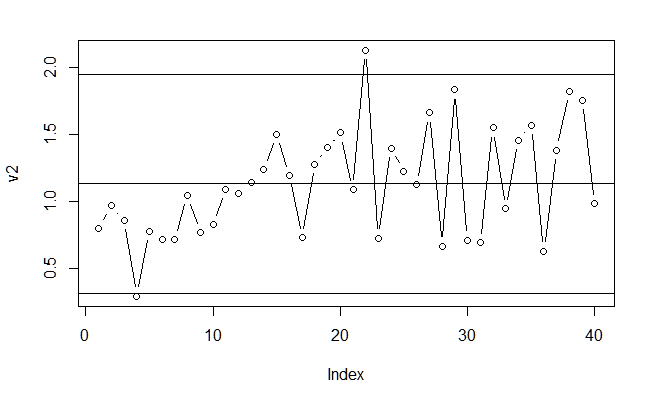

```r
abline(h=p3)
abline(h=p4)
```

```r
par(mar=c(5,4,4,5))
plot(v2, type="l")
abline(h=p1)
```

```r
abline(h=p3)
abline(h=p4)
```

```r
par(new=T)
drowPlot(week5data1, sig3min, sig3max)
```

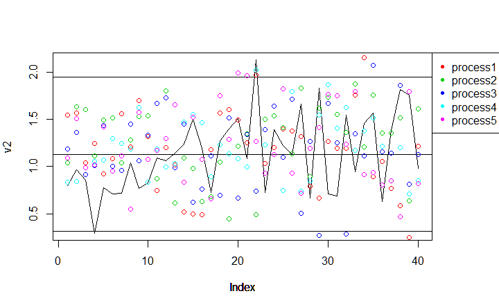

```r
par(xpd=T)
legend(par()$usr[2], par()$usr[4], legend=colnames(week5data1), pch=20, col=2:6)
```

- the greater the deviation, quality fluctuation among processes become bigger.
- fluctuation in last 20days looks bigger than first 20 days.

## 4. Construct 95% confidence interval for Standard Deviation of process which measures the true variability of internal fluid pressure.

### 1 direction, 2 scenarios.

- use Chi square estimation to estimate population from samples.
- seek interval from 5 sample groups
  - find the widest interval from min to max in each process interval
- seek interval from simgle sample group
  - find interval from 200 samples.

```r
mat = makeSummary(week5data1)
print(data.frame(mat))
```

|  | variance | X95..conf...bottom | X95..conf...top | deviation...bottom | deviation...top | mean | stndard.deviation |
| --- | --- | --- | --- | --- | --- | --- | --- |
| process 1 | 1.618441 | 1.0860140 | 2.668400 | 1.0421199 | 1.633524 | 4.85725 | 1.272180 |
| process 2 | 1.420702 | 0.9533266 | 2.342379 | 0.9763844 | 1.530483 | 5.16475 | 1.191932 |
| process 3 | 1.591497 | 1.0679340 | 2.623976 | 1.0334089 | 1.619869 | 4.84950 | 1.261546 |
| process 4 | 1.491305 | 1.0007023 | 2.458784 | 1.0003511 | 1.568051 | 4.97075 | 1.221190 |
| process 5 | 1.525051 | 1.0233472 | 2.514424 | 1.0116062 | 1.585693 | 5.02525 | 1.234930 |
| all process | 1.512357 | 1.2542063 | 1.859767 | 1.1199135 | 1.363733 | 4.97350 | 1.229779 |

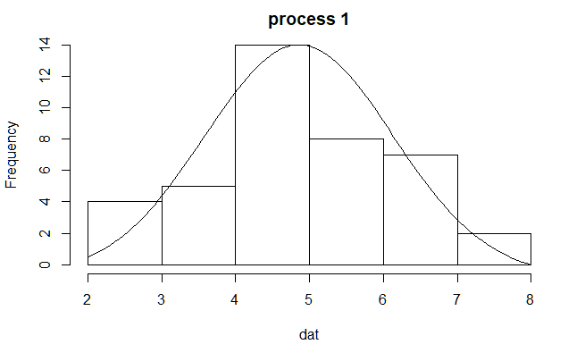

```r
drowHist(week5data1$process1, "process 1")
```

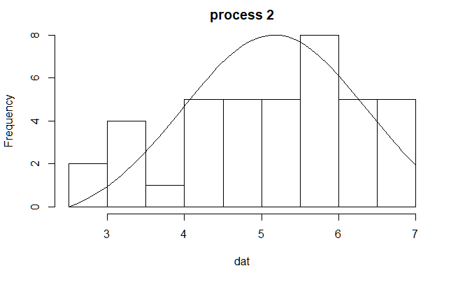

```r
drowHist(week5data1$process2, "process 2")
```

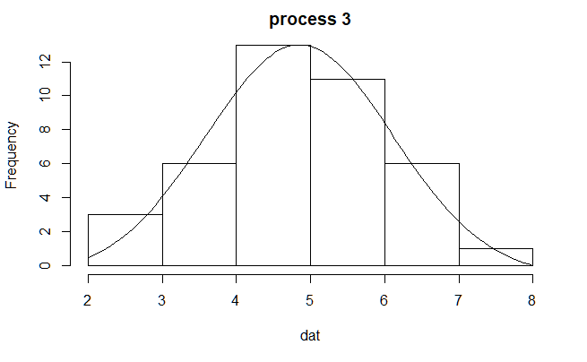

```r
drowHist(week5data1$process3, "process 3")
```

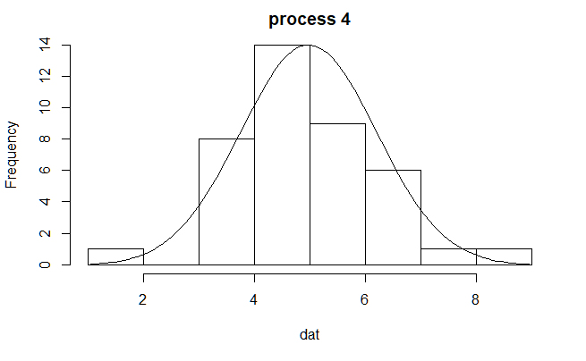

```r
drowHist(week5data1$process4, "process 4")
```

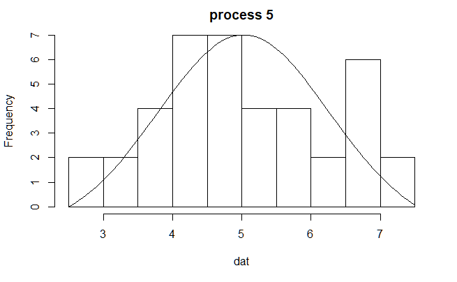

```r
drowHist(week5data1$process5, "process 5")
```

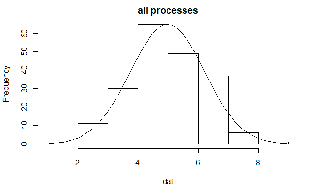

```r
drowHist(c(
  week5data1$process1,
  week5data1$process2,
  week5data1$process3,
  week5data1$process4,
  week5data1$process5
), "all processes")
```

```r
par(mar=c(5,4,4,5))
drawCurve(mat)
par(xpd=T)
```

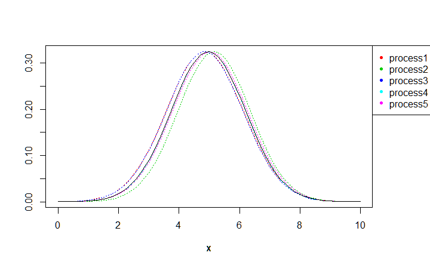

```r
legend(par()$usr[2], par()$usr[4], legend=colnames(week5data1), pch=20, col=2:6)
```

```r
print(data.frame(makeConclusion(mat)))
```

|  | mean | deviation...bottom | deviation...top | X2.sigma...bottom | X2.sigma...top |
| --- | --- | --- | --- | --- | --- |
| process 1 | 4.85725 | 1.0421199 | 1.633524 | 1.590202 | 8.124298 |
| process 2 | 5.16475 | 0.9763844 | 1.530483 | 2.103783 | 8.225717 |
| process 3 | 4.84950 | 1.0334089 | 1.619869 | 1.609761 | 8.089239 |
| process 4 | 4.97075 | 1.0003511 | 1.568051 | 1.834648 | 8.106852 |
| process 5 | 5.02525 | 1.0116062 | 1.585693 | 1.853863 | 8.196637 |
| all process | 4.97350 | 1.1199135 | 1.363733 | 2.246035 | 7.700965 |

95% confidence interval based on processes: 31.59 (1.59) - 38.23 (8.23)  
95% confidence interval based on all processes: 32.25 (2.25) - 37.70 (7.70)